# Elektrauto AG

# 2 - Alter

[figure not shown]

```
   Kunden  Besucher  maennliche Kunden
0      50      49.8               50.4
```

*--> fast keine Abweichung zwischen den Alter, alle Kunden und Besucher sind circa 50 Jahre alt*

# 3 - Multiple Linear Regression

**Die soziooekonomischen Merkmale, die den Kaufpreis beeinflussen, sind den Alter, Einkommen und Geschlecht**

**--> Das Einkommen beeinflusst am meisten den Kaufpreis**

[figure not shown]

**Mit Alter:**

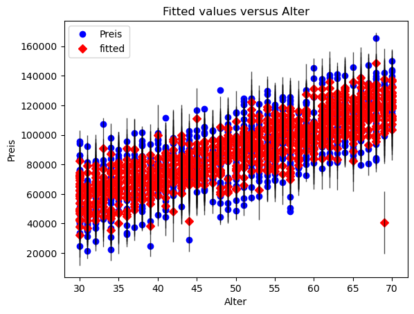

**Mit Einkommen:**

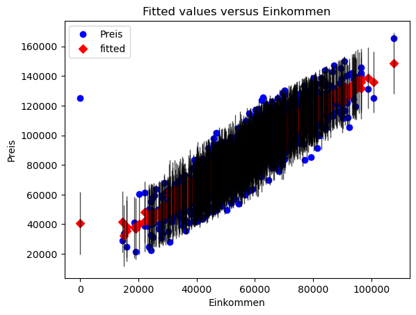

**Prognose:**

```
   Alter  Einkommen  Testzeit  Prognosierter Kaufpreis
0     32      30000        30                    50743
1     51      54000        45                    85259
```

*aeltere Kunde mit mehr Einkommen => teuere Auto*

# 4. Logistische Regression

**Wahrscheinlichkeitsberechnung:**

```
   Alter  Einkommen  Testzeit  Warhscheinlichkeit
0     32      30000        30            0.715339
1     51      54000        45            0.719300
```

*Groessere Wahrscheinlichkeit fuer Kunde 2, aelter, mit mehr Einkommen und Testzeit*

# 5. Zusammenfuehrung und Bereinigung der Dateien

- Konsistenz der Daten gewaehrleisten --> Datentypen, Trennzeichen der Nachkommastelle standardisiert
- Unsinnige Eintraege --> Identifiziert & geloescht
- "Merge" der Kunden.csv, Besucher.csv und geo.txt Dateien
- Hilfsvariable hinzugefuegt --> Kunden erkennen

# 6. Vorschlaege

I. Mehr Informationen ueber das Fahrzeug (z.B. Marke, Modell) --> Berechnung und Analyse der Profitmargen, Umsatz als auch Gewinnanteile von den einzelnen Modellen

II. Digitale Umfrage --> mehr Antworten, weniger Fehler

# Vielen Dank für Ihre Aufmerksamkeit!